# Illumina Import and Cleaning

Simon Grimm

2022-11-14

# 1 TODOs

- Make a data dictionary.
- Clean metadata
  - Integrate changed metadata, as created in this google sheet: https://docs.google.com/spreadsheets/d/1a7BHgb0_NPgey61IHlsF-RP2_EBhAUyW4e377oHQs1k/edit?usp=sharing
  - Parse notes field
  - Turn all fields into snake_case
  - Assign suitable variable types
  - Turn null into NaN
- Attach FastQC data to the metadata
  - Issue of having two files each for every sample, as CZID combined the forward and reverse (R1 & R2) of each sample into one common sample.
- Convert is_enriched to a logical with as.logical. for it to be 0/1 in the raw data, though probably should be numeric rather than integer upon reading in - discuss this
- Work through (and potentially fix) taxon_stats table creation
- Understand why CZID doesn’t assign kingdom level taxa names.
- Explain sample metadata

# 2 Background

Here I will import and clean all data required to analyze initial Illumina runs which were submitted in October 2022.

We will work with [.biom files](https://biom-format.org/), acquired from a CZID analysis of our data (link [here](https://czid.org/my_data?currentDisplay=table&currentTab=samples&mapSidebarTab=summary&projectId=4788&showFilters=true&showStats=true&updatedAt=2022-10-07T18%3A28%3A46.867Z&workflow=short-read-mngs), only available when given access. Reach out to simon@securebio.org if you do not have access)

# 3 Setup

## 3.1 R packages

We start by loading all required R packages:

```r
# set of data analysis and viz tools
library(tidyverse)

# file system helpers
library(fs)

# specifying locations within a project
library(here)

#Fastqc & Multiqc helpers
library(TidyMultiqc)

# microbiome analysis helpers
library(biomformat)
library(speedyseq)
library(vegan)

# plotting helpers
library(cowplot)
library(patchwork)
library(ggbeeswarm)
```

## 3.2 Defining directories

We then set the folder containing the `.biom` file as our `here` directory.

```r
biom_data_path <- here("data/czid")
multiqc_data_path <- here("data/fastqc_analyses/multiqc_reports/multiqc_data")
metadata_data_path <- here("data/metadata")
output_data_path <- here("output")
```

## 3.3 Data import

We now import the BIOM file (Combined Microbiome File.biom)

```r
biom <- path(biom_data_path, '2022_11_14_Illumina_pilot_nt_r.biom') %>%
  read_biom()
```

Note, if we try reading in the file as directly exported from CZID, we get an error:

```
Error in validObject(.Object) :
  invalid class “biom” object: type field has unsupported value
```

This error arises because the ‘type’ of the data object defined in the JSON-formatted contents of the `.biom` file isn’t valid as per the BIOM format v1.0 specs, see https://biom-format.org/documentation/format_versions/biom-1.0.html.

We can see this by opening up the file and looking for the type argument towards the beginning; or looking at the top items in the list after reading in the file with a JSON parser.

```r
biom_json <- path(biom_data_path,
  '2022_11_14_Illumina_pilot_nt_r.biom') %>%
  jsonlite::read_json()
biom_json %>% head(7)
```

[output not shown]

We can fix the file by changing the type from ‘Table’ to something valid. It doesn’t actually matter what we use:

For now, let’s use ‘Taxon table’.

```r
biom_text <- path(biom_data_path, '2022_11_14_Illumina_pilot_nt_r.biom') %>%
  read_file
stopifnot( identical(biom_text %>% str_count('"Table"'), 1L) )
biom_text_fixed <- biom_text %>%
  str_replace('"Table"', '"Taxon table"')
write_file(
  biom_text_fixed,
  path(output_data_path, '2022_11_14_Illumina_pilot_nt_r_fixed.biom')
)
```

The above chunk reads in the BIOM file’s contents as a single string, checks that ‘“Table”’ appears only once (in the field where it is set as the type), then replaces it with ‘“Taxon table”’), then writes the string as a new BIOM file. We should now be able to load the corrected BIOM file with the `biomformat` package,

```r
biom <- path(output_data_path, '2022_11_14_Illumina_pilot_nt_r_fixed.biom') %>% read_biom() %>%
  print
```

```
## biom object.
## type: Taxon table
## matrix_type: sparse
## 12447 rows and 12 columns
```

Note: For most objects in R, the `print()` and `glimpse()` methods silently return the object as well as printing information about it. Adding a `print` or `glimpse` call at the end of a variable-assignment pipe chain is a succinct way to save an object and show some info about it.

# 4 Creating the building blocks of a phyloseq object

The abundance (count) matrix, sample metadata table, and taxonomy table can be extracted with three corresponding functions functions from the biomformat package.

## 4.1 Abundance matrix

We’ll tackle these one at a time. First, the abundance matrix.

```r
abun <- biom %>% biom_data()
abun %>% class
```

```
## [1] "dgCMatrix"
## attr(,"package")
## [1] "Matrix"
```

```r
abun %>% dim
```

```
## [1] 12447    12
```

The abundance matrix is stored as a sparse matrix from the Matrix package. That is fine for now, though phyloseq will want a standard (dense) matrix. Next we will extract the sample metadata.

## 4.2 Sample Metadata

```r
sam <- biom %>% sample_metadata()

knitr::kable(sam)
```

|  | sample_type | nucleotide_type | collection_date | water_control | collection_location | Wastewater Plant | is_enriched | Vol | Conc | Experiment Type | Genome | Illumina ID | Notes | Pool |
| --- | --- | --- | --- | --- | --- | --- | --- | --- | --- | --- | --- | --- | --- | --- |
| 221014Esv_D22-10330:292694 | Environmental | DNA | 2020-05 | No | Massachusetts, USA | Anonymous | 0 | 13 | 3.71 | P1 | null | 1 IL | Type=genomicDNA; Notes=PEG 1 | null |
| 221014Esv_D22-10170:292695 | Environmental | DNA | 2020-05 | No | Massachusetts, USA | Anonymous | 0 | 13 | 0.8 | P2 | null | 2 IL | Type=genomicDNA; Notes=PEG 2 | null |
| 221014Esv_D22-10176:292696 | Environmental | DNA | 2020-05 | No | Massachusetts, USA | Anonymous | 0 | 13 | null | CU-C | null | 8 IL | Type=genomicDNA; Notes=Tap water (unfiltered; Ceres) | null |
| 221014Esv_D22-10331:292697 | Environmental | DNA | 2020-05 | No | Massachusetts, USA | Anonymous | 0 | 13 | 1.72 | P3 | null | 3 IL | Type=genomicDNA; Notes=PEG 3 | null |
| 221014Esv_D22-10333:292698 | Environmental | DNA | 2020-05 | No | Massachusetts, USA | Anonymous | 0 | 13 | 2.69 | CU2 | null | 6 IL | Type=genomicDNA; Notes=Ceres (unfiltered) 2 | null |
| 221014Esv_D22-10175:292699 | Environmental | DNA | 2020-05 | No | Massachusetts, USA | Anonymous | 0 | 13 | null | CF | null | 7 IL | Type=genomicDNA; Notes=Ceres (filtered) | null |
| 221014Esv_D22-10336:292700 | Environmental | DNA | 2020-05 | No | Massachusetts, USA | Anonymous | 0 | 13 | 1.7 | A3 | null | 11 IL | Type=null; Notes=Amicon 3 | null |
| 221014Esv_D22-10172:292701 | Environmental | DNA | 2020-05 | No | Massachusetts, USA | Anonymous | 0 | 13 | 0.068 | P-C | null | 4 IL | Type=genomicDNA; Notes=Tap water (PEG) | null |
| 221014Esv_D22-10180:292706 | Environmental | DNA | 2020-05 | No | Massachusetts, USA | Anonymous | 0 | 13 | null | A-C | null | 12 IL | Type=null; Notes=Tap water (Amicon) | null |
| 221014Esv_D22-10332:292707 | Environmental | DNA | 2020-05 | No | Massachusetts, USA | Anonymous | 0 | 13 | 2.32 | CU1 | null | 5 IL | Type=genomicDNA; Notes=Ceres (unfiltered) 1 | null |
| 221014Esv_D22-10334:292708 | Environmental | DNA | 2020-05 | No | Massachusetts, USA | Anonymous | 0 | 13 | 1.89 | A1 | null | 9 IL | Type=null; Notes=Amicon 1 | null |
| 221014Esv_D22-10335:292710 | Environmental | DNA | 2020-05 | No | Massachusetts, USA | Anonymous | 0 | 13 | 2.61 | A2 | null | 10 IL | Type=null; Notes=Amicon 2 | null |

```r
sam <- sam %>%
  janitor::clean_names() %>%
  glimpse
```

```
## Rows: 12
## Columns: 14
## $ sample_type         <chr> "Environmental", "Environmental", "Environmental",…
## $ nucleotide_type     <chr> "DNA", "DNA", "DNA", "DNA", "DNA", "DNA", "DNA", "…
## $ collection_date     <chr> "2020-05", "2020-05", "2020-05", "2020-05", "2020-…
## $ water_control       <chr> "No", "No", "No", "No", "No", "No", "No", "No", "N…
## $ collection_location <chr> "Massachusetts, USA", "Massachusetts, USA", "Massa…
## $ wastewater_plant    <chr> "Anonymous", "Anonymous", "Anonymous", "Anonymous"…
## $ is_enriched         <chr> "0", "0", "0", "0", "0", "0", "0", "0", "0", "0", …
## $ vol                 <chr> "13", "13", "13", "13", "13", "13", "13", "13", "1…
## $ conc                <chr> "3.71", "0.8", "null", "1.72", "2.69", "null", "1.…
## $ experiment_type     <chr> "P1", "P2", "CU-C", "P3", "CU2", "CF", "A3", "P-C"…
## $ genome              <chr> "null", "null", "null", "null", "null", "null", "n…
## $ illumina_id         <chr> "1 IL", "2 IL", "8 IL", "3 IL", "6 IL", "7 IL", "1…
## $ notes               <chr> "Type=genomicDNA; Notes=PEG 1", "Type=genomicDNA; …
## $ pool                <chr> "null", "null", "null", "null", "null", "null", "n…
```

### 4.2.1 Additional Metadata

We can now also add some additional metadata to our sample metadata. Here we first add our FASTQC data.

#### 4.2.1.1 FastQC data

First, let’s include our FASTQC data. This allows to gauge the overall quality of our sequencing runs, before any computational processing.

```r
multiqc_data <- TidyMultiqc::load_multiqc(path(multiqc_data_path, 'multiqc_data.json'))
```

When attempting to read in our `multiqc_data.json` file, either with `TidyMultiqc::load_multiqc` or with `jsonlite::read_json()`, we get an error with the following message:

```
Error in parse_con(txt, bigint_as_char) :
lexical error: invalid char in json text.
NaN,
(right here) ------^
```

After some digging this error is [found to be](https://github.com/ewels/MultiQC/issues/1509) caused by the occurrence of `NaN` in the json, which should instead be `null`, as JSON format doesn’t allow for NaN. To fix this we can simply replace `NaN` with `null` across the file, using `gseb`. This works similar to `grep` in Terminal, finding all occurrences of a string in a given file, replacing it subsequently.

```r
multiqc_text <- path(multiqc_data_path, 'multiqc_data.json') %>%
  read_file

multiqc_text_fixed <- gsub("NaN", "null", multiqc_text)

write_file(
  multiqc_text_fixed,
  path(multiqc_data_path, 'multiqc_data.json')
)
```

**ISSUE:**

We now have the issue of having two files each for every sample, as CZID combined the forward and reverse (R1 & R2) of each sample into one common sample.

```r
multiqc_data <- TidyMultiqc::load_multiqc(path(multiqc_data_path, 'multiqc_data.json')) %>%
  print
```

```
## # A tibble: 24 × 6
##    metadata.sample_id     general.percent_gc general.a…¹ gener…² gener…³ gener…⁴
##    <chr>                               <dbl>       <dbl>   <dbl>   <dbl>   <dbl>
##  1 221014Esv_D22-10180_R2                 43         300     219   0        54.5
##  2 221014Esv_D22-10175_R1                 40         300     732   3.01     63.6
##  3 221014Esv_D22-10170_R2                 42         300 1116942   3.75     36.4
##  4 221014Esv_D22-10176_R1                 41         300     661   1.51     63.6
##  5 221014Esv_D22-10172_R1                 37         300     202   0.495    54.5
##  6 221014Esv_D22-10333_R1                 42         300 1202489   0.918    45.5
##  7 221014Esv_D22-10332_R2                 43         300 1132444   0.495    45.5
##  8 221014Esv_D22-10336_R2                 42         300 1079381   3.04     45.5
##  9 221014Esv_D22-10331_R2                 42         300 1384019   4.11     36.4
## 10 221014Esv_D22-10330_R1                 39         300 1396675   4.21     36.4
## # … with 14 more rows, and abbreviated variable names
## #   ¹general.avg_sequence_length, ²general.total_sequences,
## #   ³general.percent_duplicates, ⁴general.percent_fails
```

#### 4.2.1.2 Experiment information

Cleaner version (TODO)

Finally we want to add understand samples by their experimental protocols. For this, we can parse the `notes` column in our sample data:

```r
sam %>% select(notes)
```

|  | notes |
| --- | --- |
| 221014Esv_D22-10330:292694 | Type=genomicDNA; Notes=PEG 1 |
| 221014Esv_D22-10170:292695 | Type=genomicDNA; Notes=PEG 2 |
| 221014Esv_D22-10176:292696 | Type=genomicDNA; Notes=Tap water (unfiltered; Ceres) |
| 221014Esv_D22-10331:292697 | Type=genomicDNA; Notes=PEG 3 |
| 221014Esv_D22-10333:292698 | Type=genomicDNA; Notes=Ceres (unfiltered) 2 |
| 221014Esv_D22-10175:292699 | Type=genomicDNA; Notes=Ceres (filtered) |
| 221014Esv_D22-10336:292700 | Type=null; Notes=Amicon 3 |
| 221014Esv_D22-10172:292701 | Type=genomicDNA; Notes=Tap water (PEG) |
| 221014Esv_D22-10180:292706 | Type=null; Notes=Tap water (Amicon) |
| 221014Esv_D22-10332:292707 | Type=genomicDNA; Notes=Ceres (unfiltered) 1 |

[output cut: 2 more lines]

Original, clunky version:

```r
experiment_class <- c("peg_precipitation", "peg_precipitation",
                      "peg_precipitation","peg_precipitation",
                      "ceres", "ceres", "ceres", "ceres",
                      "amicon", "amicon", "amicon", "amicon")

experiment_type <- c("P1", "P2" ,"P3", "P-C",
                     "CU1","CU2", "CF","CU-C",
                     "A1","A2","A3","A-C")

experiment_class_type <- tibble(experiment_class, experiment_type)
```

```r
sam <- sam %>%
  rownames_to_column(var = "sample_name") %>%
  as_tibble %>%
  left_join(.,experiment_class_type, by = "experiment_type", copy = TRUE)
```

Next, the taxonomy table, or what the biomformat package calls the ‘observation metadata’.

## 4.3 Taxonomy table

Note, when using glimpse we observe that taxonomy level 2 (under ‘Bacteria’) is blank. Might be worth investigating why that is.

```r
tax <- biom %>% observation_metadata()
tax %>% class
```

```
## [1] "data.frame"
```

```r
tax %>% glimpse()
```

```
## Rows: 12,447
## Columns: 8
## $ taxonomy1 <chr> "Bacteria", "Bacteria", "Bacteria", "Bacteria", "Bacteria", …
## $ taxonomy2 <chr> "", "", "", "", "", "", "", "", "", "", "", "", "", "", "", …
## $ taxonomy3 <chr> "Proteobacteria", "Proteobacteria", "Actinobacteria", "Dicty…
## $ taxonomy4 <chr> "Alphaproteobacteria", "Gammaproteobacteria", "Actinobacteri…
## $ taxonomy5 <chr> "Rhizobiales", "Enterobacterales", "Micrococcales", "Dictyog…
## $ taxonomy6 <chr> "Xanthobacteraceae", "Erwiniaceae", "Cellulomonadaceae", "Di…
## $ taxonomy7 <chr> "Azorhizobium", "Buchnera", "Cellulomonas", "Dictyoglomus", …
## $ taxonomy8 <chr> "Azorhizobium caulinodans", "Buchnera aphidicola", "Cellulom…
```

```r
tax_tmp <- biom %>% observation_metadata()
if (is.data.frame(tax_tmp)) {
  tax <- tax_tmp %>% as_tibble(rownames = '.otu')
} else {
  tax <- tax_tmp %>%
    enframe(name = 'feature_id') %>%
    unnest_wider(value)
}
rm(tax_tmp)
tax %>% glimpse
```

```
## Rows: 12,447
## Columns: 9
## $ .otu      <chr> "Bacteria;;Proteobacteria;Alphaproteobacteria;Rhizobiales;Xa…
## $ taxonomy1 <chr> "Bacteria", "Bacteria", "Bacteria", "Bacteria", "Bacteria", …
## $ taxonomy2 <chr> "", "", "", "", "", "", "", "", "", "", "", "", "", "", "", …
## $ taxonomy3 <chr> "Proteobacteria", "Proteobacteria", "Actinobacteria", "Dicty…
## $ taxonomy4 <chr> "Alphaproteobacteria", "Gammaproteobacteria", "Actinobacteri…
## $ taxonomy5 <chr> "Rhizobiales", "Enterobacterales", "Micrococcales", "Dictyog…
## $ taxonomy6 <chr> "Xanthobacteraceae", "Erwiniaceae", "Cellulomonadaceae", "Di…
## $ taxonomy7 <chr> "Azorhizobium", "Buchnera", "Cellulomonas", "Dictyoglomus", …
## $ taxonomy8 <chr> "Azorhizobium caulinodans", "Buchnera aphidicola", "Cellulom…
```

To understand this table further, we can first look at the first column. This contains the entire taxonomic structure of one organism in one variable, like so:

`Bacteria;NA;Proteobacteria;Alphaproteobacteria;Rhizobiales;Xanthobacteraceae;Azorhizobium;Azorhizobium caulinodan`

The following columns then show all the taxonomic information broken down by different taxa levels:

```r
glimpse(as_tibble(tax[1:3, 2:9]))
```

```
## Rows: 3
## Columns: 8
## $ taxonomy1 <chr> "Bacteria", "Bacteria", "Bacteria"
## $ taxonomy2 <chr> "", "", ""
## $ taxonomy3 <chr> "Proteobacteria", "Proteobacteria", "Actinobacteria"
## $ taxonomy4 <chr> "Alphaproteobacteria", "Gammaproteobacteria", "Actinobacteri…
## $ taxonomy5 <chr> "Rhizobiales", "Enterobacterales", "Micrococcales"
## $ taxonomy6 <chr> "Xanthobacteraceae", "Erwiniaceae", "Cellulomonadaceae"
## $ taxonomy7 <chr> "Azorhizobium", "Buchnera", "Cellulomonas"
## $ taxonomy8 <chr> "Azorhizobium caulinodans", "Buchnera aphidicola", "Cellulom…
```

To facilitate downstream analysis, it is helpful to clean up some of the taxonomic labels.

1. Replace the taxonomic ranks with the standard NCBI rank names (see an example [NCBI taxonomic record](https://www.ncbi.nlm.nih.gov/Taxonomy/Browser/wwwtax.cgi?id=9606))
2. In cases where the rank is missing/unassigned, replace the empty string with NA.

```r
rnks <- c('superkingdom', 'kingdom', 'phylum', 'class', 'order', 'family',
  'genus', 'species')
colnames(tax)[2:9] <- rnks
# use NA for missing ranks
tax <- tax %>%
  mutate(
    across(everything(), ~ifelse(. == "", NA_character_, .))
  )
tax %>% glimpse
```

```
## Rows: 12,447
## Columns: 9
## $ .otu         <chr> "Bacteria;;Proteobacteria;Alphaproteobacteria;Rhizobiales…
## $ superkingdom <chr> "Bacteria", "Bacteria", "Bacteria", "Bacteria", "Bacteria…
## $ kingdom      <chr> NA, NA, NA, NA, NA, NA, NA, NA, NA, NA, NA, NA, NA, NA, N…
## $ phylum       <chr> "Proteobacteria", "Proteobacteria", "Actinobacteria", "Di…
## $ class        <chr> "Alphaproteobacteria", "Gammaproteobacteria", "Actinobact…
## $ order        <chr> "Rhizobiales", "Enterobacterales", "Micrococcales", "Dict…
## $ family       <chr> "Xanthobacteraceae", "Erwiniaceae", "Cellulomonadaceae", …
## $ genus        <chr> "Azorhizobium", "Buchnera", "Cellulomonas", "Dictyoglomus…
## $ species      <chr> "Azorhizobium caulinodans", "Buchnera aphidicola", "Cellu…
```

## 4.4 Building the phyloseq object

Now let’s import all three tables into a single `phyloseq` object. This involves converting each individual table into the corresponding class from the `phyloseq` package, and then combining these into one phyloseq-class object.

```r
ps <- phyloseq(
  otu_table(abun %>% as.matrix, taxa_are_rows = TRUE),
  sample_data(sam),
  tax_table(tax)
)
```

```
## Assuming first column, `sample_name`, contains the sample names
```

```
## Assuming first column, `.otu`, contains the taxa names
```

Note that we had to first coerce the abundance matrix to a standard dense matrix; we also needed to tell phyloseq that taxa corresponded to rows in the matrix.

# 5 Basic data checks and stats

Our `phyloseq` object consists of several tables, one of which is our sample metadata:

```r
ps %>% sample_data() %>% glimpse
```

```
## Rows: 12
## Columns: 15
## $ sample_type         <chr> "Environmental", "Environmental", "Environmental",…
## $ nucleotide_type     <chr> "DNA", "DNA", "DNA", "DNA", "DNA", "DNA", "DNA", "…
## $ collection_date     <chr> "2020-05", "2020-05", "2020-05", "2020-05", "2020-…
## $ water_control       <chr> "No", "No", "No", "No", "No", "No", "No", "No", "N…
## $ collection_location <chr> "Massachusetts, USA", "Massachusetts, USA", "Massa…
## $ wastewater_plant    <chr> "Anonymous", "Anonymous", "Anonymous", "Anonymous"…
## $ is_enriched         <chr> "0", "0", "0", "0", "0", "0", "0", "0", "0", "0", …
## $ vol                 <chr> "13", "13", "13", "13", "13", "13", "13", "13", "1…
## $ conc                <chr> "3.71", "0.8", "null", "1.72", "2.69", "null", "1.…
## $ experiment_type     <chr> "P1", "P2", "CU-C", "P3", "CU2", "CF", "A3", "P-C"…
## $ genome              <chr> "null", "null", "null", "null", "null", "null", "n…
## $ illumina_id         <chr> "1 IL", "2 IL", "8 IL", "3 IL", "6 IL", "7 IL", "1…
## $ notes               <chr> "Type=genomicDNA; Notes=PEG 1", "Type=genomicDNA; …
## $ pool                <chr> "null", "null", "null", "null", "null", "null", "n…
## $ experiment_class    <chr> "peg_precipitation", "peg_precipitation", "ceres",…
```

Understanding how many individual species are covered by each sample gives us an initial large scale picture of how samples differ. We can thus add a column for our sample metadata consisting of the sum of all individual species:

```r
ps <- ps %>%
  mutate_sample_data(.,
    sample_sum = sample_sums(.)
  )
sam <- ps %>% sample_data %>% as_tibble
tax <- ps %>% tax_table %>% as_tibble
```

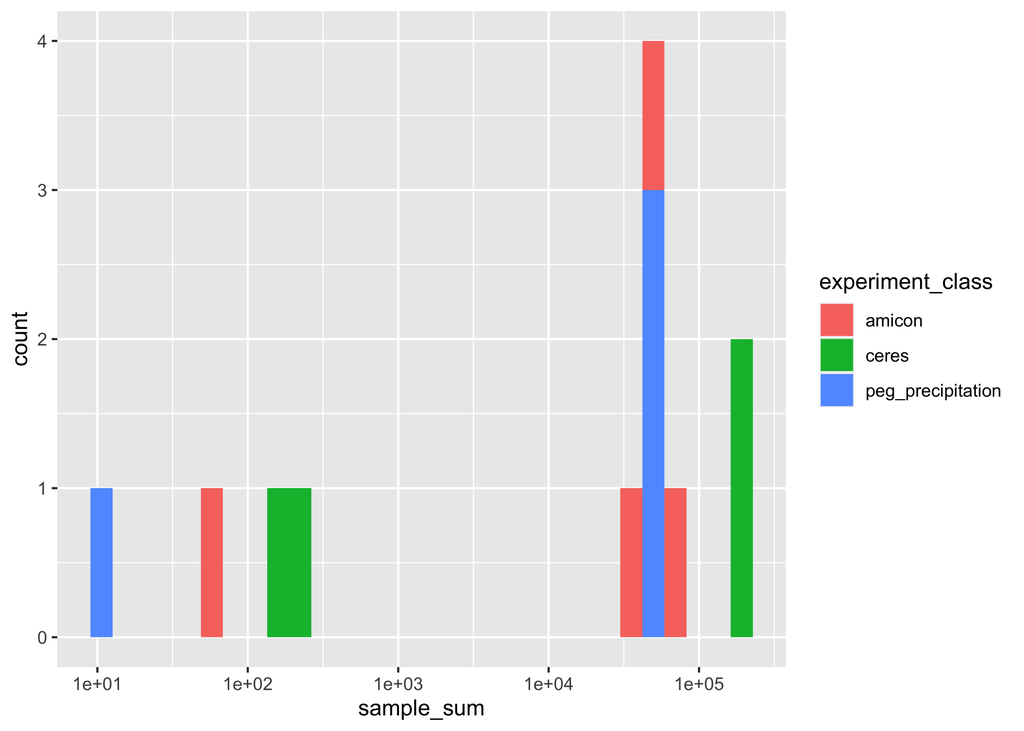

```r
sam %>%
  ggplot(aes(sample_sum, fill = experiment_class)) +
  scale_x_log10() +
  geom_histogram()
```

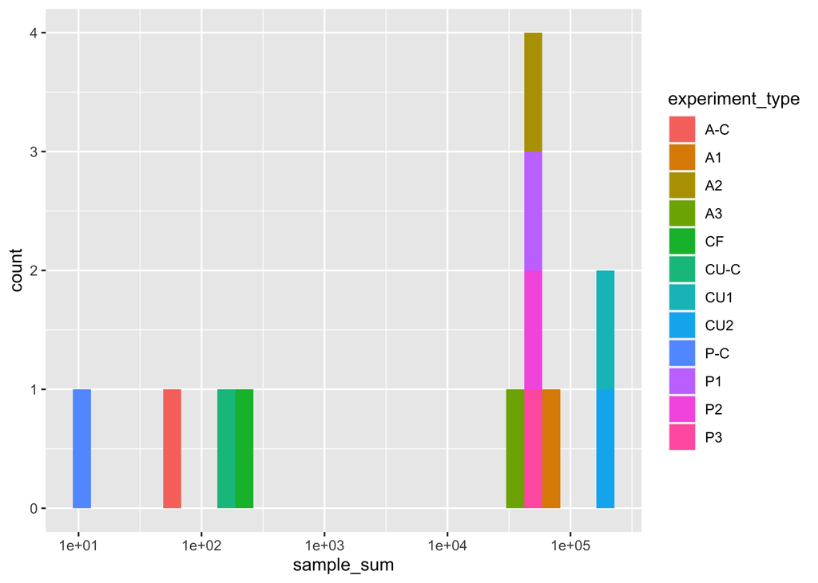

```r
sam %>%
  ggplot(aes(sample_sum, fill = experiment_type)) +
  scale_x_log10() +
  geom_histogram()
```

#### 5.0.0.1 **QUESTION:** Can we walk through the code below + potentially fix it?

```r
taxon_stats <- ps %>%
  as_tibble %>%
  mutate(across(superkingdom, fct_explicit_na)) %>%
  with_groups(c(.otu, superkingdom), summarize,
    prev_1 = sum(.abundance >= 1),
    prev_10 = sum(.abundance >= 10),
    total = sum(.abundance),
    proportion = mean(.abundance / sample_sum)
  )
```

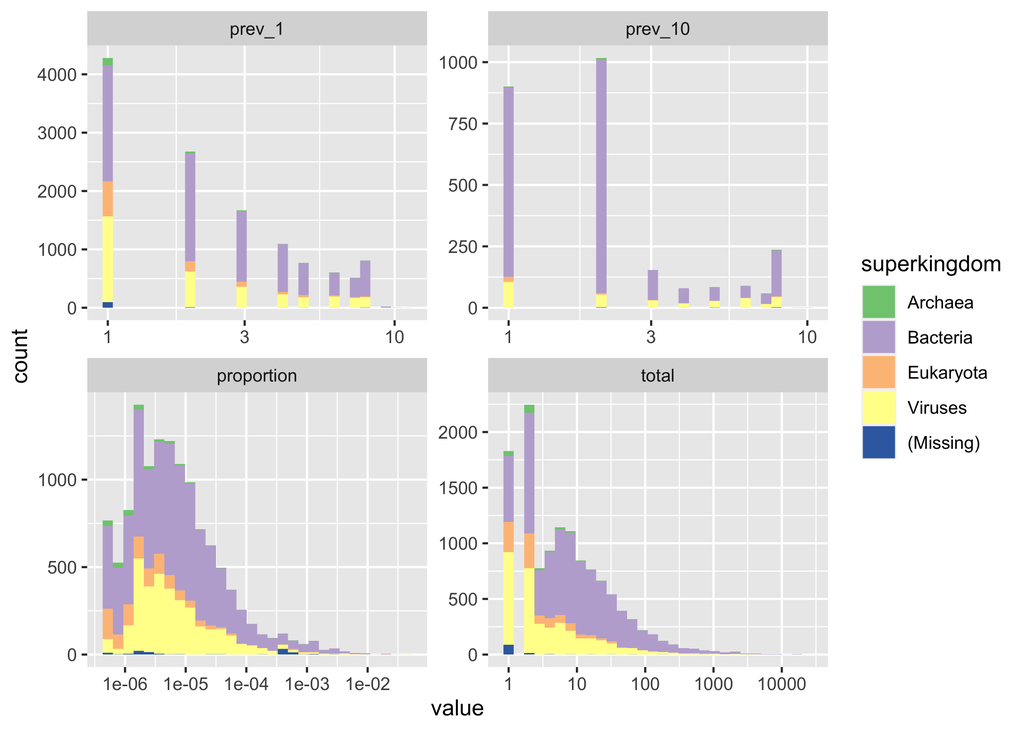

```r
taxon_stats %>%
  pivot_longer(-c(.otu, superkingdom)) %>%
  ggplot(aes(value, fill = superkingdom)) +
  facet_wrap(~name, scales = 'free') +
  scale_x_log10() +
  scale_fill_brewer(type = 'qual') +
  geom_histogram()
```

## 5.1 Taxonomy

NCBI taxonomy has recently received changes in some prokaryotic phylum names. Let’s check to see which version of phylum names are being used here, by seeing whether a Bacteroides species’ phylum is listed as ‘Bacteroidetes’ (old name) or ‘Bacteroidota’ (new name).

```r
tax %>%
  filter(genus == 'Bacteroides') %>%
  slice(1)%>%
  glimpse
```

```
## Rows: 1
## Columns: 9
## $ .otu         <chr> "Bacteria;;Bacteroidetes;Bacteroidia;Bacteroidales;Bacter…
## $ superkingdom <chr> "Bacteria"
## $ kingdom      <chr> NA
## $ phylum       <chr> "Bacteroidetes"
## $ class        <chr> "Bacteroidia"
## $ order        <chr> "Bacteroidales"
## $ family       <chr> "Bacteroidaceae"
## $ genus        <chr> "Bacteroides"
## $ species      <chr> "Bacteroides fragilis"
```

If we look at [this taxon in NCBI taxonomy](https://www.ncbi.nlm.nih.gov/Taxonomy/Browser/wwwtax.cgi?id=1263047), we can see that NCBI has adopted the new phylum name ‘Bacteroidota’; however, here we see the old phylum name. This suggests that CZID is currently using an older version of NCBI [prior to the name change](https://ncbiinsights.ncbi.nlm.nih.gov/2021/12/10/ncbi-taxonomy-prokaryote-phyla-added/).

We can now also look at the fraction of each taxa level which is classified. In total there are 12447 classified species:

```r
tax %>%
  pivot_longer(-.otu, names_to = 'rank') %>%
  with_groups(rank, summarize,
    features_classified = sum(!is.na(value)),
    features_total = n()
  ) %>%
  mutate(
    frac_classified = features_classified / features_total,
    rank = factor(rank, rank_names(ps))
  ) %>%
  arrange(rank)
```

| rank | features_classified | features_total | frac_classified |
| --- | --- | --- | --- |
| superkingdom | 12334 | 12447 | 0.99092151 |
| kingdom | 817 | 12447 | 0.06563831 |
| phylum | 11190 | 12447 | 0.89901181 |
| class | 10843 | 12447 | 0.87113361 |
| order | 10973 | 12447 | 0.88157789 |
| family | 10821 | 12447 | 0.86936611 |
| genus | 9543 | 12447 | 0.76669077 |
| species | 12447 | 12447 | 1.00000000 |

This analysis points to some notable features of the data. For example, not every taxonomic feature has a superkingdom. Let’s take a look at some of those ‘species’ that don’t:

```r
set.seed(42)
tax %>%
  filter(is.na(superkingdom)) %>%
  select(superkingdom, kingdom, genus, species) %>%
  slice_sample(n=20)
```

| superkingdom | kingdom | genus | species |
| --- | --- | --- | --- |
| NA | NA | NA | Cloning vector pSH106 |
| NA | NA | NA | Cloning vector pMSx119 |
| NA | NA | NA | Cloning vector AbVec6W-hIgKappa |
| NA | NA | NA | Cloning vector pRosa26-hisD-P.Hsp70min-loxP-STOP-loxP-Dam |
| NA | NA | NA | Cloning vector pFA-3xGFP-NAT1-Clox |
| NA | NA | NA | Cloning vector pLeo1246 |
| NA | NA | NA | Synthetic plasmid pRK123 |
| NA | NA | NA | Cloning vector pD1 |
| NA | NA | NA | Cloning vector pTacCDF-VvSTS-At4CL1m |
| NA | NA | NA | Cloning vector pCMV-CBA-Cas9-Rosa26gRNAs |

[output cut: 10 more lines]

As we see, there are some sequences that are classified as cloning and expression vectors.

What about ‘species’ without intermediate ranks?

```r
tax %>%
  filter(!is.na(superkingdom), is.na(family)) %>%
  select(superkingdom, kingdom, phylum, family, genus, species) %>%
  slice_sample(n=20)
```

| superkingdom | kingdom | phylum | family | genus | species |
| --- | --- | --- | --- | --- | --- |
| Bacteria | NA | NA | NA | NA | uncultured bacterium BD_contig02874 |
| Bacteria | NA | NA | NA | NA | uncultured bacterium BD_contig03499 |
| Bacteria | NA | NA | NA | NA | uncultured bacterium BD_contig00585 |
| Bacteria | NA | Proteobacteria | NA | NA | Gammaproteobacteria bacterium |
| Bacteria | NA | NA | NA | NA | uncultured bacterium BD_contig02215 |
| Bacteria | NA | Firmicutes | NA | NA | Clostridiales bacterium canine oral taxon 222 |
| Bacteria | NA | Planctomycetes | NA | NA | Planctomycetes bacterium SV_7m_r |
| Bacteria | NA | NA | NA | NA | uncultured bacterium BD_contig00101 |
| Eukaryota | NA | Apicomplexa | NA | Nephromyces | Nephromyces sp. MMRI |
| Bacteria | NA | Proteobacteria | NA | NA | Pseudomonas sp. ADP |

[output cut: 10 more lines]

Different than before these sequences seem to match NCBI records that aren’t well annotated (e.g., “Uncultured Bacterium”)

A further feature of CZID’s taxonomic assigment is the absence of kingdom information. As seen above, only ~800 out of ~12’000 identified species have an assigned kingdom.

Fixing this might be important, as we could be interested in analyzing samples on a kingdom level.

```r
tax %>%
  filter(!is.na(kingdom)) %>%
  select(superkingdom, kingdom, phylum, family, genus, species)
```

| superkingdom | kingdom | phylum | family | genus | species |
| --- | --- | --- | --- | --- | --- |
| Eukaryota | Viridiplantae | Streptophyta | Rutaceae | Citrus | Citrus limon |
| Eukaryota | Viridiplantae | Streptophyta | Rutaceae | Citrus | Citrus sinensis |
| Eukaryota | Viridiplantae | Chlorophyta | Chlamydomonadaceae | Chlamydomonas | Chlamydomonas reinhardtii |
| Eukaryota | Viridiplantae | Chlorophyta | Volvocaceae | Volvox | Volvox carteri |
| Eukaryota | Viridiplantae | Chlorophyta | Codiaceae | Codium | Codium fragile |
| Eukaryota | Viridiplantae | Streptophyta | Chlorokybaceae | Chlorokybus | Chlorokybus atmophyticus |
| Eukaryota | Viridiplantae | Chlorophyta | Pedinomonadaceae | Pedinomonas | Pedinomonas minor |
| Eukaryota | Viridiplantae | Chlorophyta | Chlorodendraceae | Scherffelia | Scherffelia dubia |
| Eukaryota | Viridiplantae | Streptophyta | Marchantiaceae | Marchantia | Marchantia polymorpha |
| Eukaryota | Viridiplantae | Streptophyta | Funariaceae | Physcomitrium | Physcomitrium patens |

[output cut: 807 more lines]

Lastly we can look at how species break down by superkingdom:

```r
tax %>%
  count(superkingdom) %>%
  mutate(fraction = n / sum(n))
```

| superkingdom | n | fraction |
| --- | --- | --- |
| Archaea | 203 | 0.016309151 |
| Bacteria | 7748 | 0.622479312 |
| Eukaryota | 997 | 0.080099622 |
| Viruses | 3386 | 0.272033422 |
| NA | 113 | 0.009078493 |

## 5.2 Saving our curated data

Finally, we can save our created phyloseq object, so we can use it in the following Rmd analyses. We do this by writing an R object (here a phyloseq object) into an RDS file.

```r
saveRDS(ps, here(output_data_path, "2022_12_08_illumina_phyloseq.Rds"))
```